# Prediction.Assignment.Writeup.Final

Atair Camargo

July, 2019

## Prediction Assignment Writeup

### Background

Using devices such as Jawbone Up, Nike FuelBand, and Fitbit it is now possible to collect a large amount of data about personal activity relatively inexpensively. These type of devices are part of the quantified self movement – a group of enthusiasts who take measurements about themselves regularly to improve their health, to find patterns in their behavior, or because they are tech geeks. One thing that people regularly do is quantify how much of a particular activity they do, but they rarely quantify how well they do it. In this project, your goal will be to use data from accelerometers on the belt, forearm, arm, and dumbell of 6 participants. They were asked to perform barbell lifts correctly and incorrectly in 5 different ways. More information is available from the website here: http://web.archive.org/web/20161224072740/http:/groupware.les.inf.puc-rio.br/har (see the section on the Weight Lifting Exercise Dataset).

### Data

The training data for this project are available here: https://d396qusza40orc.cloudfront.net/predmachlearn/pml-training.csv

The test data are available here: https://d396qusza40orc.cloudfront.net/predmachlearn/pml-testing.csv

### Downloading and assigning Data Files

```
Base and test data sets are downloaded and loaded into two files.
```

```r
#Assign files' urls
plm.train.url <- "https://d396qusza40orc.cloudfront.net/predmachlearn/pml-training.csv"

plm.test.url <- "https://d396qusza40orc.cloudfront.net/predmachlearn/pml-testing.csv"


#assign files names
train.file <- "pml-training.csv"

test.file <- "pml-testing.csv"

#download the files
if (!file.exists(train.file)){
    download.file(plm.train.url, train.file)
}

if (!file.exists(test.file)){
    download.file(plm.test.url, test.file)
}

#load data into tables
plm.train.data <- read.csv(file = "pml-training.csv", header = TRUE, sep = ",", na.strings=c("#DIV/0!"," ", "", "NA", "NAs", "NULL"))
plm.test.data <- read.csv(file = "pml-testing.csv", header = TRUE, sep = ",", na.strings=c("#DIV/0!"," ", "", "NA", "NAs", "NULL"))
dim(plm.train.data)
```

```
## [1] 19622   160
```

```r
dim(plm.test.data)
```

```
## [1]  20 160
```

### Data Cleaning

Visualizing the data, it can be seen several NAs, so NAs will be removed from Data.Frame.

```r
# Remove NAs
clean.plm.train.data <- plm.train.data[, which(colSums(is.na(plm.train.data)) == 0)]

clean.plm.test.data <- plm.test.data[, which(colSums(is.na(plm.test.data)) == 0)]
#Checking Reduction
dim(clean.plm.train.data)
```

```
## [1] 19622    60
```

```r
dim(clean.plm.test.data)
```

```
## [1] 20 60
```

### Data Transformation

It can be seen that the first 7 columns are not relevant to prediction, so they will be removed.

```r
#Remove columns
final.plm.train.data <- clean.plm.train.data[,-c(1:7)]
final.plm.test.data <- clean.plm.test.data[,-c(1:7)]
dim(final.plm.train.data)
```

```
## [1] 19622    53
```

```r
dim(final.plm.test.data)
```

```
## [1] 20 53
```

### Data Slicing

Data will be split in order to perform validation.

```r
library(caret)
#Split 60% of the data
plm.inTrain <- createDataPartition(y=final.plm.train.data$classe, p=0.60, list=FALSE )

plm.train <- final.plm.train.data[plm.inTrain,]

plm.valid <- final.plm.train.data[-plm.inTrain,]

#Check data sets dimensions
dim(plm.train)
```

```
## [1] 11776    53
```

```r
dim(plm.valid)
```

```
## [1] 7846   53
```

```r
dim(final.plm.test.data)
```

```
## [1] 20 53
```

### Define Pre Process Method

```r
#Define Pre Process Method
library("caret")
control <- trainControl(method="cv", number=3, p = 0.75, classProbs = TRUE, preProcOptions= "pca", allowParallel=TRUE)
```

### Building Models

Modelling with Random Forest. Checking hardware performance as well.

```r
# Random Forest
set.seed(2018)
system.time(fit.td.rf <- train(classe~., data=plm.train, method="rf", metric = "ROC", maximize = TRUE, trControl=control))
```

```
##    user  system elapsed
##  354.27    4.31  370.36
```

Modelling with boosted trees “GBM”.

```r
# GBM
set.seed(2018)
system.time(fit.td.gbm <- train(classe~., data=plm.train, method="gbm", metric = "ROC", maximize = TRUE, trControl=control, verbose = FALSE))
```

```
##    user  system elapsed
##  133.06    0.55  137.66
```

```r
# summarizing results
set.seed(2018)
results <- resamples(list(rf=fit.td.rf, gbm=fit.td.gbm))
# Comparison Table
summary(results)
```

```
##
## Call:
## summary.resamples(object = results)
##
## Models: rf, gbm
## Number of resamples: 3
##
## Accuracy
##          Min.   1st Qu.    Median      Mean   3rd Qu.      Max. NA's
## rf  0.9852154 0.9856049 0.9859944 0.9864128 0.9870115 0.9880285    0
## gbm 0.9544065 0.9567042 0.9590018 0.9579659 0.9597456 0.9604894    0
##
## Kappa
##          Min.   1st Qu.    Median      Mean   3rd Qu.      Max. NA's
## rf  0.9812975 0.9817894 0.9822813 0.9828109 0.9835676 0.9848538    0
## gbm 0.9423134 0.9452188 0.9481243 0.9468205 0.9490740 0.9500237    0
```

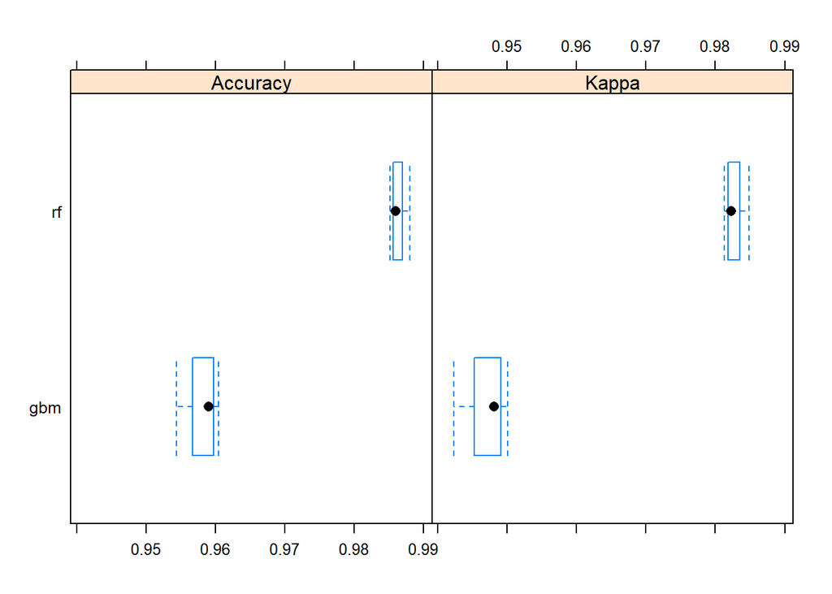

```r
# boxplot comparison
bwplot(results)
```

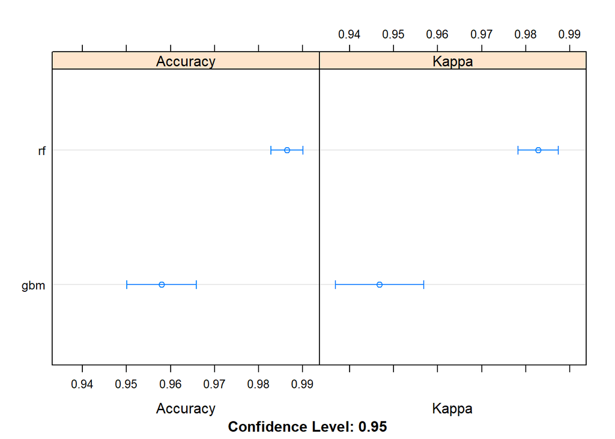

```r
# Dot-plot comparison
dotplot(results)
```

```r
pred1 <- predict(fit.td.rf, plm.valid)
confusionMatrix(plm.valid$classe, pred1)
```

```
## Confusion Matrix and Statistics
##
##           Reference
## Prediction    A    B    C    D    E
##          A 2229    0    2    0    1
##          B    1 1517    0    0    0
##          C    0    7 1359    2    0
##          D    0    0    2 1283    1
##          E    0    0    0    2 1440
##
## Overall Statistics
##
##                Accuracy : 0.9977
##                  95% CI : (0.9964, 0.9986)
##     No Information Rate : 0.2842
##     P-Value [Acc > NIR] : < 2.2e-16
##
##                   Kappa : 0.9971
##
##  Mcnemar's Test P-Value : NA
##
## Statistics by Class:
##
##                      Class: A Class: B Class: C Class: D Class: E
## Sensitivity            0.9996   0.9954   0.9971   0.9969   0.9986
## Specificity            0.9995   0.9998   0.9986   0.9995   0.9997
## Pos Pred Value         0.9987   0.9993   0.9934   0.9977   0.9986
## Neg Pred Value         0.9998   0.9989   0.9994   0.9994   0.9997
## Prevalence             0.2842   0.1942   0.1737   0.1640   0.1838
## Detection Rate         0.2841   0.1933   0.1732   0.1635   0.1835
## Detection Prevalence   0.2845   0.1935   0.1744   0.1639   0.1838
## Balanced Accuracy      0.9995   0.9976   0.9978   0.9982   0.9992
```

```r
pred2 <- predict(fit.td.gbm, plm.valid)
confusionMatrix(plm.valid$classe, pred2)
```

```
## Confusion Matrix and Statistics
##
##           Reference
## Prediction    A    B    C    D    E
##          A 2195   26   10    1    0
##          B   46 1436   32    1    3
##          C    0   39 1309   19    1
##          D    2    3   33 1239    9
##          E    4   11   17   16 1394
##
## Overall Statistics
##
##                Accuracy : 0.9652
##                  95% CI : (0.9609, 0.9692)
##     No Information Rate : 0.2864
##     P-Value [Acc > NIR] : < 2.2e-16
##
##                   Kappa : 0.956
##
##  Mcnemar's Test P-Value : 1.375e-06
##
## Statistics by Class:
##
##                      Class: A Class: B Class: C Class: D Class: E
## Sensitivity            0.9769   0.9479   0.9343   0.9710   0.9908
## Specificity            0.9934   0.9870   0.9908   0.9928   0.9925
## Pos Pred Value         0.9834   0.9460   0.9569   0.9635   0.9667
## Neg Pred Value         0.9907   0.9875   0.9858   0.9944   0.9980
## Prevalence             0.2864   0.1931   0.1786   0.1626   0.1793
## Detection Rate         0.2798   0.1830   0.1668   0.1579   0.1777
## Detection Prevalence   0.2845   0.1935   0.1744   0.1639   0.1838
## Balanced Accuracy      0.9851   0.9675   0.9626   0.9819   0.9917
```

### Result

Results show that the random forest model has the highest accuracy in cross validation. Therefore, it will be used for prediction.

### Prediction

Random forest model for prediction

```r
pred <- predict(fit.td.rf, newdata=final.plm.test.data)
pred
```

```
##  [1] B A B A A E D B A A B C B A E E A B B B
## Levels: A B C D E
```